# Watershed Regression - Part 1: Linear Mixed Models

Christian Nilsen

## License

> Copyright (c) 2020 Geosyntec Consultants, Inc. [Mozilla Public License Version 2.0](https://choosealicense.com/licenses/mpl-2.0/)

This software is provided “as is”, without warranty of any kind, express or implied, including but not limited to the warranties of merchantability, fitness for a particular purpose and noninfringement. In no event shall the authors or copyright holders be liable for any claim, damages or other liability, whether in an action of contract, tort or otherwise, arising from, out of or in connection with the software or the use or other dealings in the software.

# Description

This notebook uses spatial predictors and outfall monitoring data to develop predictive linear regression relationships. This represents the first step in the watershed regression for the stormwater heatmap. The second step is a censored bayesian model, which adds some capabilities that simple linear models do not have. This first step is necessary to select the most predictive parameters in an efficient way.

Here are the steps in the code below:

1. Code set up
2. Get and prepare monitoring data
3. Merge spatial data with monitoring data
4. Remove mulitcolinear predictors
5. Peform model selection
6. Select the best model (these results are then used in the Bayesian model in step 2)

# Setup

clear workspace and load libraries. (code not shown in html file )

# Get and prepare monitoring data

The stormwater outfall data is available from the Department of Ecology at https://data.wa.gov/Natural-Resources-Environment/Municipal-Stormwater-Permit-Outfall-Data/d958-q2ci.

A .csv file is saved in `WatershedRegression/data/S8_data.csv`

```r
all.S8.data <- read.csv("data/S8_data.csv",
                        stringsAsFactors = FALSE )

#filter out rejected data
all.S8.data <- (filter(all.S8.data,!result_data_qualifier %in% 'REJ'))

#filter out replicates
all.S8.data <- (filter(all.S8.data,!sample_replicate_flag %in% 'Y'))

#change nondetect warnings to detects
warnings <- all.S8.data$nondetect_flag == "WARNING"
all.S8.data$nondetect_flag[warnings] <- FALSE

#Change NA to detect
all.S8.data$nondetect_flag[is.na(all.S8.data$nondetect_flag)] <- FALSE

#Change season to factor
all.S8.data$season <- as.factor(all.S8.data$season)
```

The chunk below makes a list of parameters we are interested in.

```r
#Select Parameters
params <- c('Zinc - Water - Total',
 'Copper - Water - Total',
 'Nitrite-Nitrate - Water - Dissolved',
    'Lead - Water - Total',
 'Total Phosphorus - Water - Total',
 'Total Suspended Solids - Water - Total',
 'Total Phthalate - Water - Total',
'Total PAH - Water - Total',
#'Chrysene - Water - Total',
'CPAH - Water - Total',
'HPAH - Water - Total'
#'Total Kjeldahl Nitrogen - Water - Total',
#'Total PCB - Water - Total'
)

#save a list of all the parameters in case we want to use mor.
params.all <- data.frame(unique(all.S8.data$parameter))
s8data <- all.S8.data
kable(params,col.names = "Constituents of concern")
```

| Constituents of concern |
| --- |
| Zinc - Water - Total |
| Copper - Water - Total |
| Nitrite-Nitrate - Water - Dissolved |
| Lead - Water - Total |
| Total Phosphorus - Water - Total |
| Total Suspended Solids - Water - Total |
| Total Phthalate - Water - Total |
| Total PAH - Water - Total |
| CPAH - Water - Total |
| HPAH - Water - Total |

```r
#
```

Clean up extracted data and rename columns:

```r
s8data <- all.S8.data %>%

  dplyr::select(
    study_name,
    location_id,parameter,
    type,
    season,
    new_result_value,
    nondetect_flag,
    study_id,
    access_id,
    field_collection_end_date,
    field_collection_start_date,
    type)


#rename some columns
colnames(s8data)[colnames(s8data) == "location_id"] <- "Location"
colnames(s8data)[colnames(s8data) == "new_result_value"] <-
  "concentration"
s8data$nondetect_flag <- as.logical(s8data$nondetect_flag)
s8data$concentration <- as.numeric(s8data$concentration)
```

## Check for outliers

Set up a jitter plot of all the data to look for outliers:

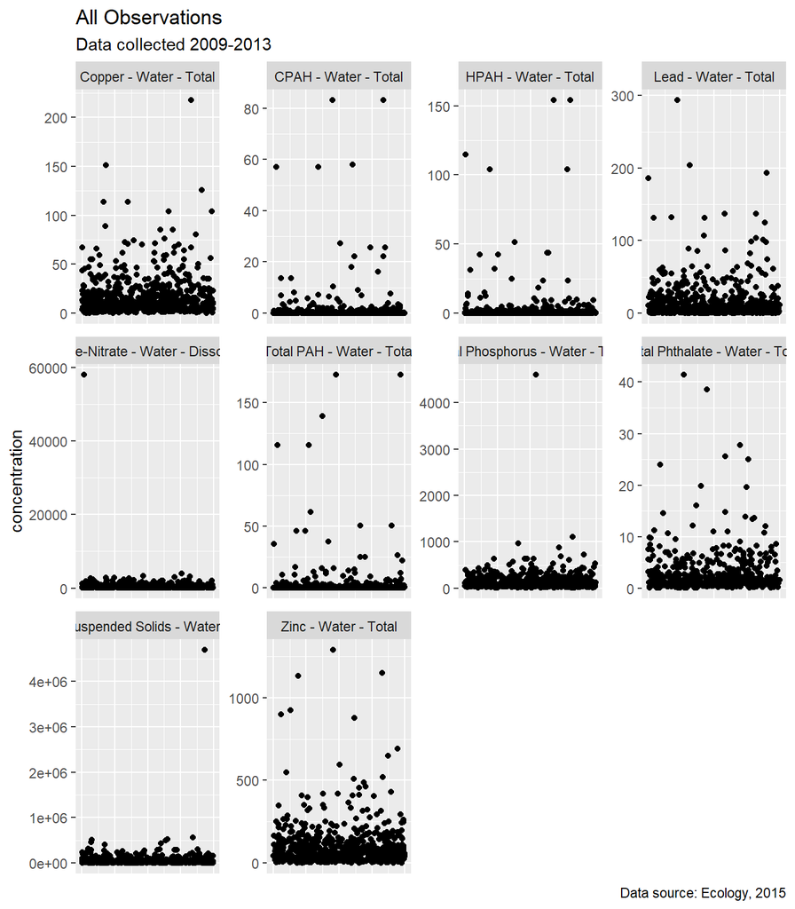

```r
#make a function for scatter plots
scatter_cocs <- function(df.coc,title) {
 p <- ggplot(df.coc, aes(1, concentration)) + geom_jitter() + labs(
  title = title,
  subtitle = "Data collected 2009-2013",
  caption =
    " Data source: Ecology, 2015",
  x = "Observations"
  #y = y.title
)
p + facet_wrap( ~ parameter, scales = 'free')+theme(axis.title.x=element_blank(),
        axis.text.x=element_blank(),
        axis.ticks.x=element_blank())
}

scatter_cocs(s8data[which(s8data$parameter %in% params),],'All Observations')
```

outliers are apprent for TSS, TP, and no2-no3. Remove these.

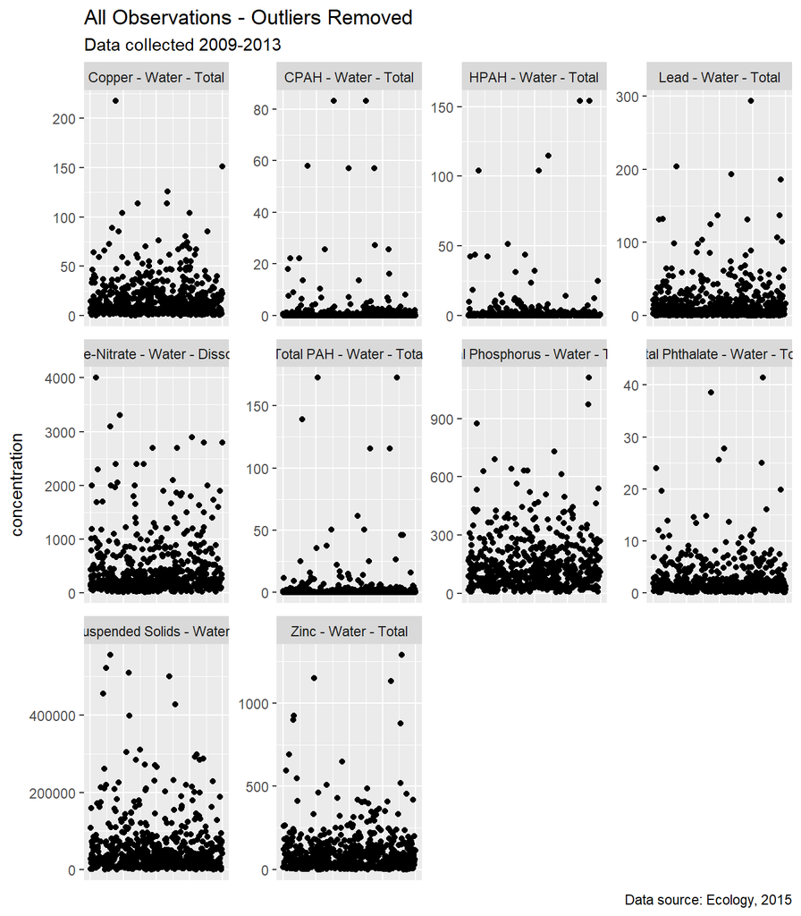

```r
#remove and replot

outlierParams <- c("Total Suspended Solids - Water - Total", "Total Phosphorus - Water - Total", "Nitrite-Nitrate - Water - Dissolved")

#This removes the highest values
outlierVals <-
  top_n(group_by(s8data[which(s8data$parameter %in% outlierParams), ], parameter), 1, concentration)$concentration

s8data <- s8data %>%
  group_by(parameter) %>%
  slice(which(!(
    parameter %in% outlierParams & concentration %in% outlierVals
  )))

scatter_cocs(s8data[which(s8data$parameter %in% params),],'All Observations - Outliers Removed')
```

Looks better. Move on to the next Chunk.

# Get Spatial data and merge

```r
#Spatial predcitors have been extracted and saved as a csv file.
#spatial_data<-read_csv("data/spatialPredictors_4_13.csv", col_types = cols(X1 = col_skip()))
spatial_data <- read_csv("C:/Users/cnilsen/Google Drive/repos/spatialPredictors.csv")
#RES and COM are compositional data. Change to a ratio
spatial_data$LU_ratio = spatial_data$COM/spatial_data$RES
spatial_data <- dplyr::select(spatial_data, -c(RES,COM,.geo))
#merge spatial predictors with monitoring data
s8data.wPredictors <<- merge(s8data, spatial_data)%>%
  dplyr::select(-c(depSplusN))

kable(head(s8data.wPredictors),caption = "S8 Monitoring Data")
```

S8 Monitoring Data

| Location | study_name | parameter | type | season | concentration | nondetect_flag | study_id | access_id | field_collection_end_date | field_collection_start_date | system:index | impervious | logPopulation | nighttime_lights | pm25 | rev_logTraffic | roadDensity | LU_ratio |
| --- | --- | --- | --- | --- | --- | --- | --- | --- | --- | --- | --- | --- | --- | --- | --- | --- | --- | --- |
| KICCOMS8D_OUT | King County Phase I Municipal Stormwater Permit | Copper - Water - Total | COM | 4 | 22.800 | FALSE | WAR044501_S8D | 36149 | 11/2/2011 | 11/2/2011 | 0000000000000000000e | 0.127 | -0.624 | -1.97 | -0.847 | -1.34 | 0.154 | -0.653 |
| KICCOMS8D_OUT | King County Phase I Municipal Stormwater Permit | LPAH - Water - Total | COM | 1 | 0.060 | FALSE | WAR044501_S8D | 102225 | NA | 2/12/2011 | 0000000000000000000e | 0.127 | -0.624 | -1.97 | -0.847 | -1.34 | 0.154 | -0.653 |
| KICCOMS8D_OUT | King County Phase I Municipal Stormwater Permit | Dichlobenil - Water - Total | COM | 4 | 0.047 | TRUE | WAR044501_S8D | 35675 | 11/1/2010 | 11/1/2010 | 0000000000000000000e | 0.127 | -0.624 | -1.97 | -0.847 | -1.34 | 0.154 | -0.653 |
| KICCOMS8D_OUT | King County Phase I Municipal Stormwater Permit | Cadmium - Water - Total | COM | 4 | 0.065 | FALSE | WAR044501_S8D | 33689 | 10/19/2012 | 10/18/2012 | 0000000000000000000e | 0.127 | -0.624 | -1.97 | -0.847 | -1.34 | 0.154 | -0.653 |
| KICCOMS8D_OUT | King County Phase I Municipal Stormwater Permit | Fecal coliform - Water - Total | COM | 4 | 530.000 | FALSE | WAR044501_S8D | 39755 | 12/8/2010 | 12/8/2010 | 0000000000000000000e | 0.127 | -0.624 | -1.97 | -0.847 | -1.34 | 0.154 | -0.653 |
| KICCOMS8D_OUT | King County Phase I Municipal Stormwater Permit | Bis(2-ethylhexyl) phthalate - Water - Total | COM | 4 | 1.270 | TRUE | WAR044501_S8D | 38768 | 11/23/2012 | 11/23/2012 | 0000000000000000000e | 0.127 | -0.624 | -1.97 | -0.847 | -1.34 | 0.154 | -0.653 |

```r
getBaseFormula <- function(df.coc) {
  #Function to make a formula for prediction
  predictors <- df.coc %>%
    select_if(is.numeric) %>%
    dplyr::select(-c(concentration, access_id)) %>%
    colnames()
  return(as.formula(paste(
    "(concentration) ~",  (paste((predictors),  collapse = " + ")), " + (1|Location)"
  )))

}
```

# Perform Linear Regression

Below, we perform linear regression one parameter at a time.

## Functions for regression

We set up a series of functions to make the analysis easier.

#### Data dictionary for these functions

`coc`: constituent of concern  
`df.coc`: filtered dataframe  
`model`: basic linear mixed model  
`log_model`: linear-mixed model with log-transformed concentrations  
`model_with_seasonality`: linear-mixed model with seasonality as an added factor  
`model_with_seasonality_log`: linear-mixed model with seasonality as an added factor with log-transformed concentrations

### Plotting function

Basic function to plot results by location

```r
plot_s8 <- function(coc) {
    df.coc <- (base::subset(s8data.wPredictors,
                parameter == coc))
  #plot the data to inspect
  plot <- ggplot(data=(df.coc))+geom_point(aes(x=Location,y=concentration),alpha = 0.5, color = "#0088a3")+scale_y_log10()+labs(
      y = "Concentration (µg/L)",
      x = "Location",
      title =  "Measured Concentrations",
      subtitle = coc ) + theme( axis.text.x = element_text(angle=90, size = 9))
  return(plot)
}
```

## Function to remove mulitcolinear predictors in base model

```r
# #Calculate variance-inflation factors.
#
# calc_vif_base <- function(coc) {
#   df.coc <- (base::subset(s8data.wPredictors,
#                 parameter == coc))
#   base_formula <- getBaseFormula(df.coc)#returns a formula with all predictors
#   model.1 <<- lmer(base_formula, data = df.coc, na.action = na.omit)
#   v <- sort(vif(model.1),decreasing=TRUE)
#   return(v)
#   #kable(v,caption="Variance Inflation Factors - not filtered") #display the vif of the dataset
# }
```

## Function to iteratively remove mulitcolinear predictors

Same as above, expect multicolinear predictors are removed.

```r
## *Check VIF

check_vif <- function(coc) {
  df.coc <- (base::subset(s8data.wPredictors,
                parameter == coc))
  base_formula <- getBaseFormula(df.coc)#returns a formula with all predictors
  model.1 <- lmer(base_formula, data = df.coc, na.action = na.omit) #make into a lmer object
  v <- sort(vif(model.1),decreasing=TRUE)

  #if the VIF of the highest ranked predictor is >10 then iteratively remove
  model_object <- model.1 #start with model object as the base model (all predictors included)


  for (i in 1:20) {
    interim_v <- sort(vif(model_object), decreasing = TRUE)
    if (max(interim_v) < 10) {
      break
    }
    predictor_to_drop = as.name(names(interim_v)[which(interim_v == max(interim_v))])
    model_object <-
      stats::update(model_object, paste(".~ . -", predictor_to_drop))
    }

  m1Terms <- (labels(terms(model.1)))
  m2Terms <- labels(terms(model_object))

  #compare the terms to get a list of the dropped terms
  droppedTerms <- setdiff(m1Terms, m2Terms)

  #make a list of selected predictors
  predictors <- m2Terms#colnames(model.frame(model_object))


  #filter df.coc to remove dropped terms.
  df.coc = dplyr::select(df.coc, -(droppedTerms))
  return(list("vif" = interim_v,"dropped" = droppedTerms,"predictors" = predictors))
  #kable(droppedTerms,caption = "These terms were dropped")

  #kable(interim_v,caption="Variance Inflation Factors - multicolinear factors dropped")
}
```

## Function to perform stepwise selection and return a series of best models

```r
## Stepwise Selection

#forward_selection(TRUE,coc,model_info$predictors)

# Extract the model that step found:

#perform forward selection on model parameters. First for non-transformed data, then for log-transformed data
forward_selection <- function(seasonal.bin, coc,predictors) {
  #seasonal.bin = binary (T/F) if seasonal model should be used
  library(lmerTest)
  #make this a lmer object
  df.coc <- (base::subset(s8data.wPredictors,
                parameter == coc))
  model_object_formula <- as.formula(paste(
    "concentration ~",  (paste((predictors),  collapse = " + ")), " + (1|Location)"))

  model_object <- lmer(model_object_formula,data=df.coc)

  step.2 <-  lmerTest::step(model_object,reduce.random=FALSE,data=df.coc)
  step.2.log <- lmerTest::step(stats::update(model_object, log(concentration)~.))

  #extract the models
  model.3 <- get_model(step.2)
  model.3.log <- get_model(step.2.log)

  #perform forward selection on model parameters, this time add seasonality . First for non-transformed data, then for log-transformed data
  step.4 <- lmerTest::step(stats::update(model_object,.~.+season))
  step.4.log <- lmerTest::step(stats::update(model_object,log(concentration) ~.+season))
  model.4 <- get_model(step.4)
  model.4.log <- get_model(step.4.log)

  #get formulas
  model.3.formula <- as.formula(model.3@call$formula)
  model.3.log.formula <- as.formula(model.3.log@call$formula)
  model.4.formula <- as.formula(model.4@call$formula)
  model.4.log.formula <- as.formula(model.4.log@call$formula)

  #detach lmer test and remove the models. Keep the formulas.
  detach("package:lmerTest", unload=TRUE)
  rm(model.3,model.3.log,model.4,model.4.log)

  #use lmer for performing modeling
  #calculate base model
  df.coc <- (base::subset(s8data.wPredictors,
                parameter == coc))
  model.base <- lmer(model_object_formula,data=df.coc)
  model <- lmer(model.3.formula,data=df.coc)
  log_model<-  lmer(model.3.log.formula,data=df.coc)

  if(seasonal.bin) {
      #if seasonal model switch is on, calc seasonal models
    model_with_seasonality <- lmer(model.4.formula,data=df.coc)
    model_with_seasonality_log <- lmer(model.4.log.formula,data=df.coc)
      #add to list
    modelList <- c(model,log_model,model_with_seasonality,model_with_seasonality_log)

    }
    else {
    modelList <-c(model,log_model)
    modelLables <-c('linear','log-linear')
    }



 return(modelList)#,show.aic = TRUE)# = FALSE, title=coc, dv.labels = modelLables)
  # #make a table of coefficients
  # tab_model(modelList,
  #   model_log,
  #   model_with_seasonality,
  #   model.with_seasonality_log,
  #   show.aic = TRUE,auto.label = FALSE, title=coc, dv.labels = c('linear','log-linear','linear seasonal','log-linear seasonal'))#file=paste0("results/",coc,".html"))
}
```

## Run through model selection functions

Now we use the functions from above to return model tables. We wrap a helper function to call the others.

```r
results = c()
plots = c()
vifs = c()
tabs = c()
for (i in 1:length(params)){
coc = params[i]
df.coc <- (base::subset(s8data.wPredictors,
                parameter == coc))
plots[[coc]] <- plot_s8(coc)
model_info <- check_vif(coc)
vifs[[coc]] <- model_info$vif

results[[coc]] = forward_selection(TRUE,coc,model_info$predictors)}
modelLabels <-c('linear','log-linear','linear seasonal','log-linear seasonal')
```

Wrapper function for displaying results for individual cocs.

```r
show_results <- function(j){
#get parameter label
lab = names(results)[j]

#plot observed
print(plots[[j]])

#show variance inflation factors
print(kable(vifs[[j]],caption = paste("Variance inflation factors",lab),col.names = c("vif")))

#show raw summary of results
models <- results[[j]]
for (k in 1:2){
  print((summary(models[[k]])))
  #plot(models[[k]],,main=paste(lab,"\n","Resididuals"))
  print(qqmath(models[[k]],main=paste(lab,"\n",modelLabels[k],"\n","QQ plot of resididuals")))
}


#formatted table of results
tabs = (tab_model(models,title=lab,show.aic = TRUE,dv.labels =modelLabels,viewer=FALSE ))
 return(tabs)

}
```

Now we can specify one parameters at a time and display the results. Generally, the model with the lowest AIC is used in Step 2 (Bayesian modeling).

## Zinc

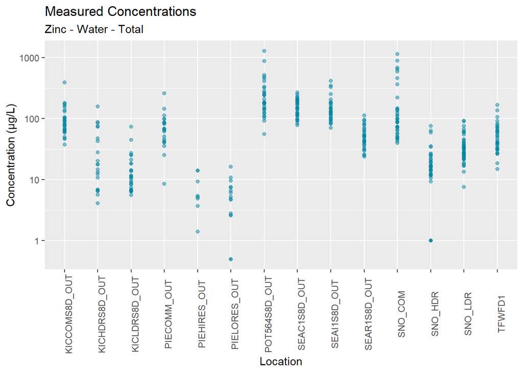

```
##
##
## Table: Variance inflation factors Zinc - Water - Total
##
##                      vif
## -----------------  -----
## nighttime_lights    4.50
## impervious          4.24
## rev_logTraffic      1.91
## logPopulation       1.89
## LU_ratio            1.29
## Linear mixed model fit by REML ['lmerMod']
## Formula: concentration ~ impervious + (1 | Location)
##    Data: df.coc
##
## REML criterion at convergence: 5088
##
## Scaled residuals:
##    Min     1Q Median     3Q    Max
## -1.846 -0.265 -0.083  0.055  9.197
##
## Random effects:
##  Groups   Name        Variance Std.Dev.
##  Location (Intercept)  1810     42.5
##  Residual             12497    111.8
## Number of obs: 414, groups:  Location, 14
##
## Fixed effects:
##             Estimate Std. Error t value
## (Intercept)    83.80      12.82    6.54
## impervious     48.05       9.32    5.16
##
## Correlation of Fixed Effects:
##            (Intr)
## impervious -0.071
```

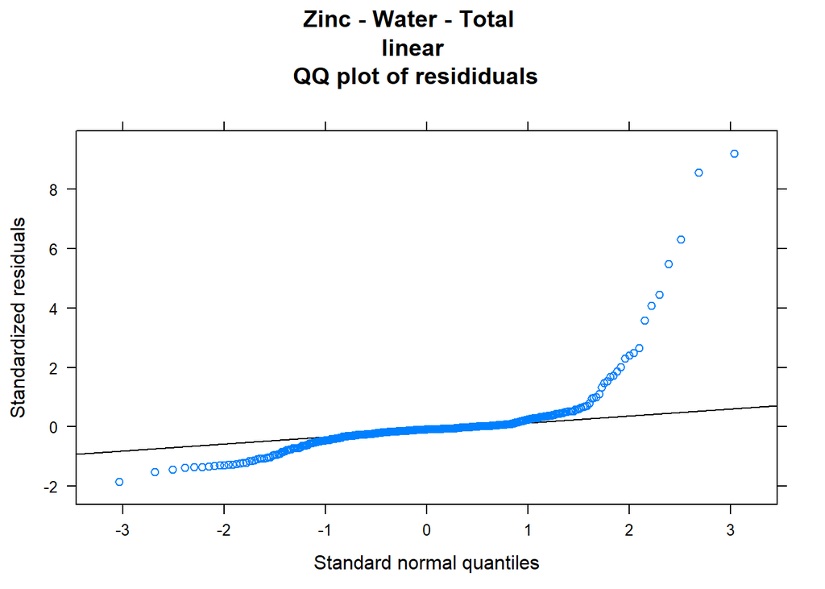

```
## Linear mixed model fit by REML ['lmerMod']
## Formula: log(concentration) ~ impervious + (1 | Location)
##    Data: df.coc
##
## REML criterion at convergence: 914
##
## Scaled residuals:
##    Min     1Q Median     3Q    Max
## -3.859 -0.524 -0.038  0.470  3.300
##
## Random effects:
##  Groups   Name        Variance Std.Dev.
##  Location (Intercept) 0.494    0.703
##  Residual             0.472    0.687
## Number of obs: 414, groups:  Location, 14
##
## Fixed effects:
##             Estimate Std. Error t value
## (Intercept)    3.639      0.192   18.99
## impervious     0.716      0.139    5.15
##
## Correlation of Fixed Effects:
##            (Intr)
## impervious -0.040
```

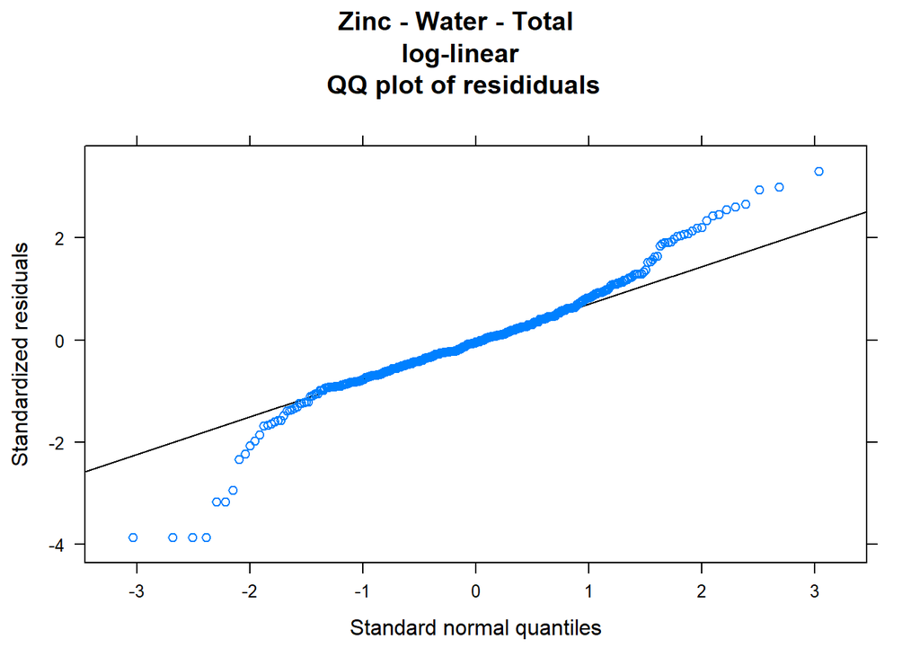

Zinc - Water - Total

|  | linear |  |  | log-linear |  |  | linear seasonal |  |  | log-linear seasonal |  |  |
| --- | --- | --- | --- | --- | --- | --- | --- | --- | --- | --- | --- | --- |
| Predictors | Estimates | CI | p | Estimates | CI | p | Estimates | CI | p | Estimates | CI | p |
| (Intercept) | 83.80 | 58.68 – 108.93 | **<0.001** | 3.64 | 3.26 – 4.01 | **<0.001** | 68.71 | 40.42 – 96.99 | **<0.001** | 3.62 | 3.24 – 3.99 | **<0.001** |
| impervious | 48.05 | 29.80 – 66.31 | **<0.001** | 0.72 | 0.44 – 0.99 | **<0.001** | 46.99 | 29.18 – 64.79 | **<0.001** | 0.71 | 0.44 – 0.98 | **<0.001** |
| season [2] |  |  |  |  |  |  | 4.22 | -25.91 – 34.34 | 0.784 | -0.07 | -0.26 – 0.13 | 0.500 |
| season [3] |  |  |  |  |  |  | 114.53 | 78.88 – 150.17 | **<0.001** | 0.39 | 0.16 – 0.62 | **0.001** |
| season [4] |  |  |  |  |  |  | 7.93 | -16.74 – 32.60 | 0.529 | 0.00 | -0.15 – 0.16 | 0.976 |
| Random Effects |  |  |  |  |  |  |  |  |  |  |  |  |
| σ<sup>2</sup> | 12496.95 |  |  | 0.47 |  |  | 11366.26 |  |  | 0.46 |  |  |
| τ<sub>00</sub> | 1809.55 <sub>Location</sub> |  |  | 0.49 <sub>Location</sub> |  |  | 1739.85 <sub>Location</sub> |  |  | 0.48 <sub>Location</sub> |  |  |
| ICC | 0.13 |  |  | 0.51 |  |  | 0.13 |  |  | 0.51 |  |  |
| N | 14 <sub>Location</sub> |  |  | 14 <sub>Location</sub> |  |  | 14 <sub>Location</sub> |  |  | 14 <sub>Location</sub> |  |  |
| Observations | 414 |  |  | 414 |  |  | 414 |  |  | 414 |  |  |
| Marginal R<sup>2</sup> / Conditional R<sup>2</sup> | 0.229 / 0.326 |  |  | 0.494 / 0.753 |  |  | 0.290 / 0.384 |  |  | 0.503 / 0.756 |  |  |
| AIC | 5095.699 |  |  | 921.495 |  |  | 5038.647 |  |  | 921.976 |  |  |

```r
(show_results(1))
```

## Copper

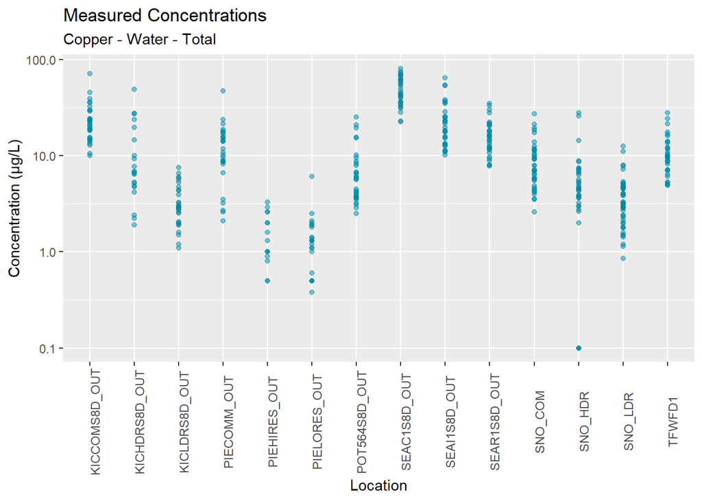

```
##
##
## Table: Variance inflation factors Copper - Water - Total
##
##                      vif
## -----------------  -----
## nighttime_lights    4.45
## impervious          4.24
## rev_logTraffic      1.92
## logPopulation       1.88
## LU_ratio            1.30
## Linear mixed model fit by REML ['lmerMod']
## Formula: concentration ~ rev_logTraffic + (1 | Location)
##    Data: df.coc
##
## REML criterion at convergence: 3139
##
## Scaled residuals:
##    Min     1Q Median     3Q    Max
## -3.131 -0.470 -0.116  0.176  5.632
##
## Random effects:
##  Groups   Name        Variance Std.Dev.
##  Location (Intercept) 44.7     6.69
##  Residual             70.5     8.40
## Number of obs: 438, groups:  Location, 14
##
## Fixed effects:
##                Estimate Std. Error t value
## (Intercept)       67.25       9.63    6.99
## rev_logTraffic    34.36       5.99    5.74
##
## Correlation of Fixed Effects:
##             (Intr)
## rev_lgTrffc 0.982
```

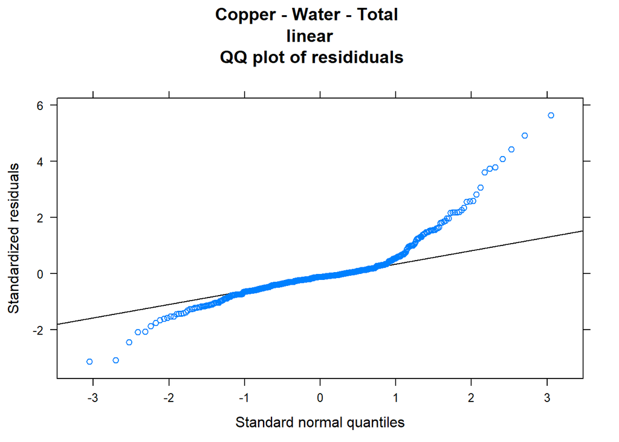

```
## Linear mixed model fit by REML ['lmerMod']
## Formula: log(concentration) ~ impervious + rev_logTraffic + (1 | Location)
##    Data: df.coc
##
## REML criterion at convergence: 931
##
## Scaled residuals:
##    Min     1Q Median     3Q    Max
## -5.392 -0.535  0.001  0.552  3.057
##
## Random effects:
##  Groups   Name        Variance Std.Dev.
##  Location (Intercept) 0.273    0.523
##  Residual             0.444    0.667
## Number of obs: 438, groups:  Location, 14
##
## Fixed effects:
##                Estimate Std. Error t value
## (Intercept)       5.408      0.803    6.74
## impervious        0.297      0.111    2.67
## rev_logTraffic    2.201      0.499    4.41
##
## Correlation of Fixed Effects:
##             (Intr) imprvs
## impervious  -0.344
## rev_lgTrffc  0.984 -0.344
```

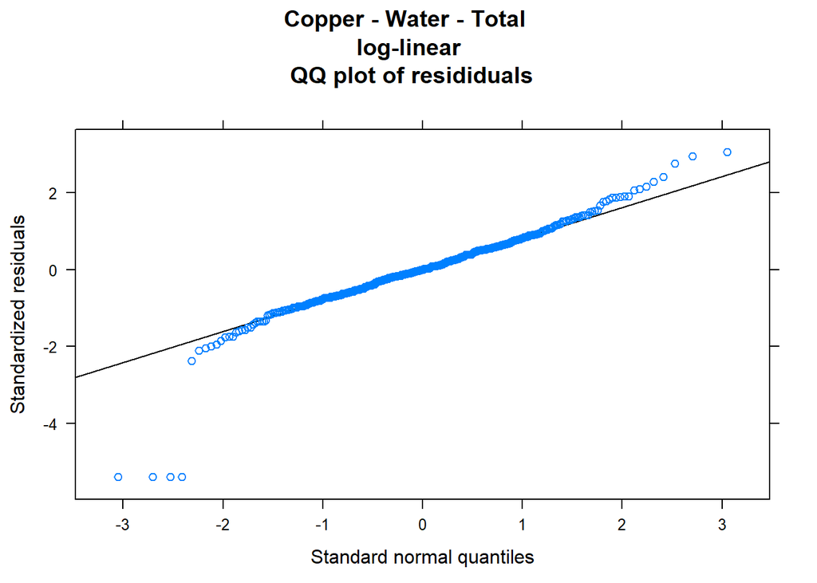

Copper - Water - Total

|  | linear |  |  | log-linear |  |  | linear seasonal |  |  | log-linear seasonal |  |  |
| --- | --- | --- | --- | --- | --- | --- | --- | --- | --- | --- | --- | --- |
| Predictors | Estimates | CI | p | Estimates | CI | p | Estimates | CI | p | Estimates | CI | p |
| (Intercept) | 67.25 | 48.38 – 86.13 | **<0.001** | 5.41 | 3.84 – 6.98 | **<0.001** | 67.29 | 48.41 – 86.17 | **<0.001** | 5.41 | 3.84 – 6.98 | **<0.001** |
| rev_logTraffic | 34.36 | 22.63 – 46.10 | **<0.001** | 2.20 | 1.22 – 3.18 | **<0.001** | 34.58 | 22.86 – 46.31 | **<0.001** | 2.20 | 1.22 – 3.18 | **<0.001** |
| impervious |  |  |  | 0.30 | 0.08 – 0.51 | **0.007** |  |  |  | 0.30 | 0.08 – 0.51 | **0.007** |
| season [2] |  |  |  |  |  |  | -0.71 | -2.93 – 1.50 | 0.528 |  |  |  |
| season [3] |  |  |  |  |  |  | 6.38 | 3.77 – 9.00 | **<0.001** |  |  |  |
| season [4] |  |  |  |  |  |  | -0.68 | -2.53 – 1.17 | 0.470 |  |  |  |
| Random Effects |  |  |  |  |  |  |  |  |  |  |  |  |
| σ<sup>2</sup> | 70.54 |  |  | 0.44 |  |  | 66.16 |  |  | 0.44 |  |  |
| τ<sub>00</sub> | 44.71 <sub>Location</sub> |  |  | 0.27 <sub>Location</sub> |  |  | 44.74 <sub>Location</sub> |  |  | 0.27 <sub>Location</sub> |  |  |
| ICC | 0.39 |  |  | 0.38 |  |  | 0.40 |  |  | 0.38 |  |  |
| N | 14 <sub>Location</sub> |  |  | 14 <sub>Location</sub> |  |  | 14 <sub>Location</sub> |  |  | 14 <sub>Location</sub> |  |  |
| Observations | 438 |  |  | 438 |  |  | 438 |  |  | 438 |  |  |
| Marginal R<sup>2</sup> / Conditional R<sup>2</sup> | 0.494 / 0.690 |  |  | 0.525 / 0.706 |  |  | 0.512 / 0.709 |  |  | 0.525 / 0.706 |  |  |
| AIC | 3146.801 |  |  | 940.604 |  |  | 3116.708 |  |  | 940.604 |  |  |

```r
show_results(2)
```

## Nitrite-Nitrate

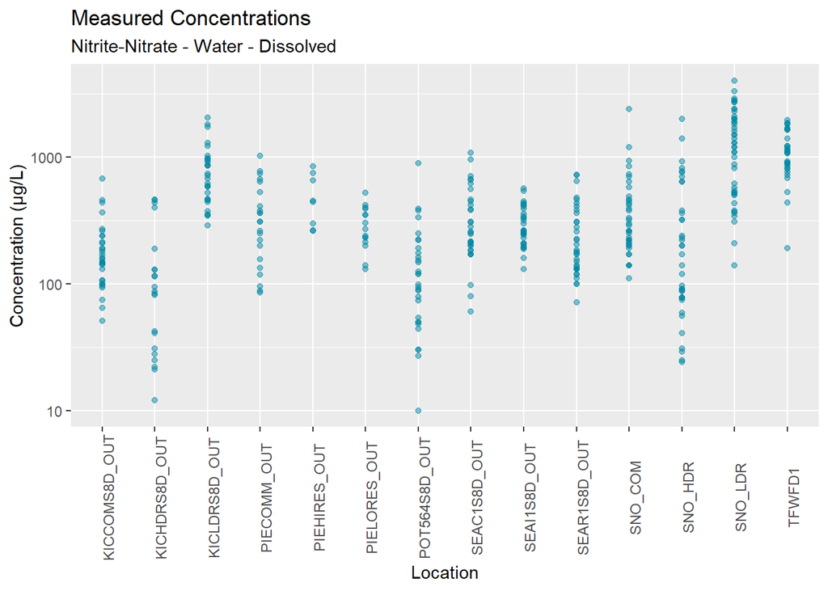

```
##
##
## Table: Variance inflation factors Nitrite-Nitrate - Water - Dissolved
##
##                      vif
## -----------------  -----
## nighttime_lights    4.45
## impervious          4.23
## rev_logTraffic      1.92
## logPopulation       1.88
## LU_ratio            1.30
## Linear mixed model fit by REML ['lmerMod']
## Formula: concentration ~ LU_ratio + (1 | Location)
##    Data: df.coc
##
## REML criterion at convergence: 6094
##
## Scaled residuals:
##    Min     1Q Median     3Q    Max
## -2.926 -0.400 -0.157  0.235  6.046
##
## Random effects:
##  Groups   Name        Variance Std.Dev.
##  Location (Intercept) 107632   328
##  Residual             185073   430
## Number of obs: 406, groups:  Location, 14
##
## Fixed effects:
##             Estimate Std. Error t value
## (Intercept)    496.1       90.9    5.46
## LU_ratio        79.9       35.2    2.27
##
## Correlation of Fixed Effects:
##          (Intr)
## LU_ratio 0.074
```

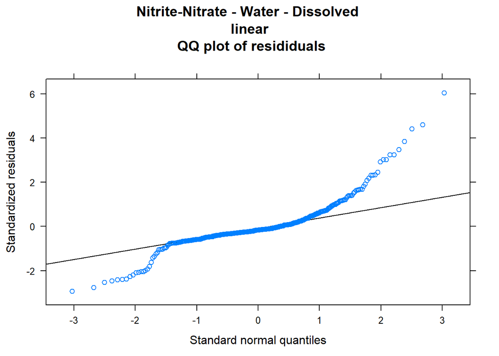

```
## Linear mixed model fit by REML ['lmerMod']
## Formula: log(concentration) ~ LU_ratio + (1 | Location)
##    Data: df.coc
##
## REML criterion at convergence: 962
##
## Scaled residuals:
##    Min     1Q Median     3Q    Max
## -3.200 -0.620 -0.005  0.590  3.236
##
## Random effects:
##  Groups   Name        Variance Std.Dev.
##  Location (Intercept) 0.428    0.654
##  Residual             0.558    0.747
## Number of obs: 406, groups:  Location, 14
##
## Fixed effects:
##             Estimate Std. Error t value
## (Intercept)   5.7185     0.1799   31.79
## LU_ratio      0.1592     0.0698    2.28
##
## Correlation of Fixed Effects:
##          (Intr)
## LU_ratio 0.073
```

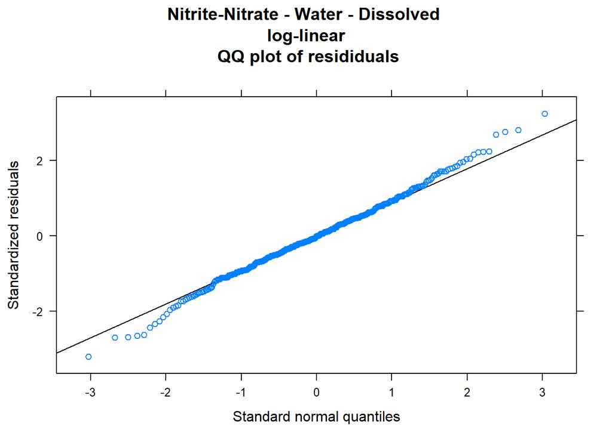

Nitrite-Nitrate - Water - Dissolved

|  | linear |  |  | log-linear |  |  | linear seasonal |  |  | log-linear seasonal |  |  |
| --- | --- | --- | --- | --- | --- | --- | --- | --- | --- | --- | --- | --- |
| Predictors | Estimates | CI | p | Estimates | CI | p | Estimates | CI | p | Estimates | CI | p |
| (Intercept) | 496.14 | 317.88 – 674.39 | **<0.001** | 5.72 | 5.37 – 6.07 | **<0.001** | 575.78 | 389.75 – 761.81 | **<0.001** | 5.81 | 5.45 – 6.16 | **<0.001** |
| LU_ratio | 79.94 | 10.88 – 149.01 | **0.023** | 0.16 | 0.02 – 0.30 | **0.023** | 80.83 | 12.29 – 149.37 | **0.021** | 0.16 | 0.03 – 0.29 | **0.019** |
| season [2] |  |  |  |  |  |  | -109.12 | -231.14 – 12.89 | 0.080 | -0.01 | -0.22 – 0.19 | 0.885 |
| season [3] |  |  |  |  |  |  | 16.24 | -130.58 – 163.05 | 0.828 | 0.48 | 0.24 – 0.73 | **<0.001** |
| season [4] |  |  |  |  |  |  | -165.25 | -264.46 – -66.03 | **0.001** | -0.37 | -0.53 – -0.21 | **<0.001** |
| Random Effects |  |  |  |  |  |  |  |  |  |  |  |  |
| σ<sup>2</sup> | 185073.43 |  |  | 0.56 |  |  | 180488.75 |  |  | 0.50 |  |  |
| τ<sub>00</sub> | 107631.70 <sub>Location</sub> |  |  | 0.43 <sub>Location</sub> |  |  | 105950.38 <sub>Location</sub> |  |  | 0.41 <sub>Location</sub> |  |  |
| ICC | 0.37 |  |  | 0.43 |  |  | 0.37 |  |  | 0.45 |  |  |
| N | 14 <sub>Location</sub> |  |  | 14 <sub>Location</sub> |  |  | 14 <sub>Location</sub> |  |  | 14 <sub>Location</sub> |  |  |
| Observations | 406 |  |  | 406 |  |  | 406 |  |  | 406 |  |  |
| Marginal R<sup>2</sup> / Conditional R<sup>2</sup> | 0.128 / 0.449 |  |  | 0.147 / 0.517 |  |  | 0.146 / 0.462 |  |  | 0.206 / 0.567 |  |  |
| AIC | 6102.003 |  |  | 969.788 |  |  | 6065.056 |  |  | 933.650 |  |  |

```r
show_results(3)
```

## Lead

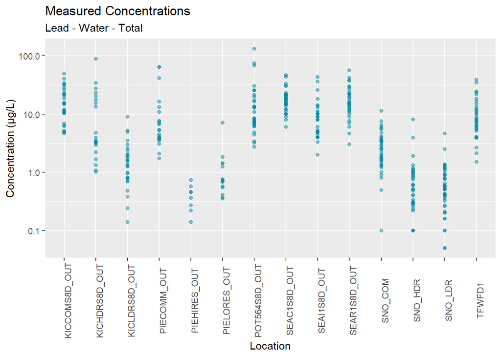

```
##
##
## Table: Variance inflation factors Lead - Water - Total
##
##                      vif
## -----------------  -----
## nighttime_lights    4.49
## impervious          4.24
## rev_logTraffic      1.91
## logPopulation       1.88
## LU_ratio            1.29
## Linear mixed model fit by REML ['lmerMod']
## Formula: concentration ~ impervious + (1 | Location)
##    Data: df.coc
##
## REML criterion at convergence: 3242
##
## Scaled residuals:
##    Min     1Q Median     3Q    Max
## -1.403 -0.437 -0.096  0.024  9.825
##
## Random effects:
##  Groups   Name        Variance Std.Dev.
##  Location (Intercept)  30.5     5.53
##  Residual             132.6    11.51
## Number of obs: 417, groups:  Location, 14
##
## Fixed effects:
##             Estimate Std. Error t value
## (Intercept)     9.10       1.60    5.69
## impervious      3.52       1.16    3.03
##
## Correlation of Fixed Effects:
##            (Intr)
## impervious -0.061
```

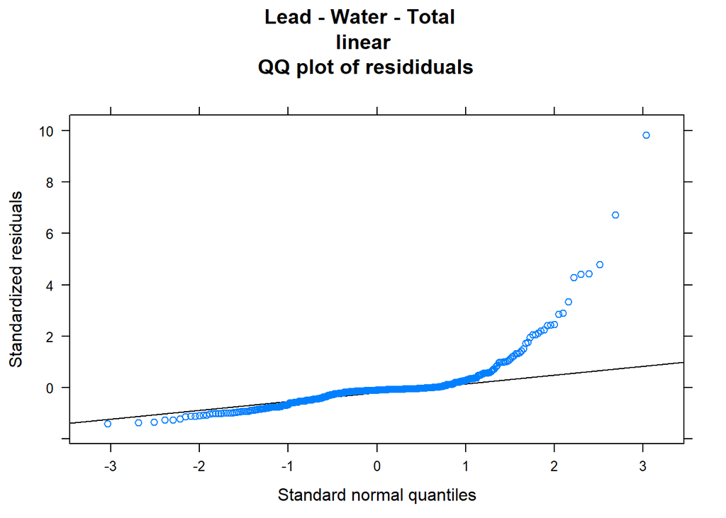

```
## Linear mixed model fit by REML ['lmerMod']
## Formula: log(concentration) ~ impervious + (1 | Location)
##    Data: df.coc
##
## REML criterion at convergence: 1083
##
## Scaled residuals:
##    Min     1Q Median     3Q    Max
## -3.777 -0.633 -0.018  0.581  3.307
##
## Random effects:
##  Groups   Name        Variance Std.Dev.
##  Location (Intercept) 1.21     1.10
##  Residual             0.69     0.83
## Number of obs: 417, groups:  Location, 14
##
## Fixed effects:
##             Estimate Std. Error t value
## (Intercept)    1.198      0.297    4.03
## impervious     0.649      0.216    3.01
##
## Correlation of Fixed Effects:
##            (Intr)
## impervious -0.037
```

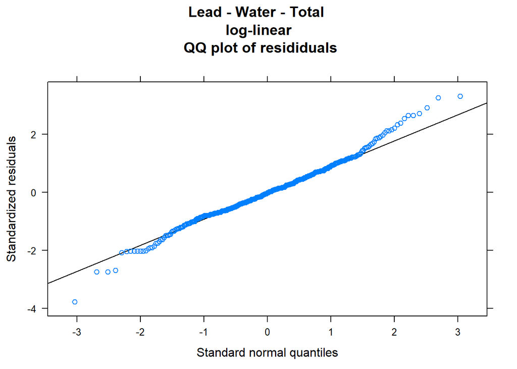

Lead - Water - Total

|  | linear |  |  | log-linear |  |  | linear seasonal |  |  | log-linear seasonal |  |  |
| --- | --- | --- | --- | --- | --- | --- | --- | --- | --- | --- | --- | --- |
| Predictors | Estimates | CI | p | Estimates | CI | p | Estimates | CI | p | Estimates | CI | p |
| (Intercept) | 9.10 | 5.97 – 12.24 | **<0.001** | 1.20 | 0.62 – 1.78 | **<0.001** | 9.10 | 5.97 – 12.24 | **<0.001** | 1.20 | 0.62 – 1.78 | **<0.001** |
| impervious | 3.52 | 1.24 – 5.79 | **0.002** | 0.65 | 0.23 – 1.07 | **0.003** | 3.52 | 1.24 – 5.79 | **0.002** | 0.65 | 0.23 – 1.07 | **0.003** |
| Random Effects |  |  |  |  |  |  |  |  |  |  |  |  |
| σ<sup>2</sup> | 132.56 |  |  | 0.69 |  |  | 132.56 |  |  | 0.69 |  |  |
| τ<sub>00</sub> | 30.53 <sub>Location</sub> |  |  | 1.21 <sub>Location</sub> |  |  | 30.53 <sub>Location</sub> |  |  | 1.21 <sub>Location</sub> |  |  |
| ICC | 0.19 |  |  | 0.64 |  |  | 0.19 |  |  | 0.64 |  |  |
| N | 14 <sub>Location</sub> |  |  | 14 <sub>Location</sub> |  |  | 14 <sub>Location</sub> |  |  | 14 <sub>Location</sub> |  |  |
| Observations | 417 |  |  | 417 |  |  | 417 |  |  | 417 |  |  |
| Marginal R<sup>2</sup> / Conditional R<sup>2</sup> | 0.122 / 0.287 |  |  | 0.290 / 0.742 |  |  | 0.122 / 0.287 |  |  | 0.290 / 0.742 |  |  |
| AIC | 3250.500 |  |  | 1090.813 |  |  | 3250.500 |  |  | 1090.813 |  |  |

```r
show_results(4)
```

## Total Phosphorus

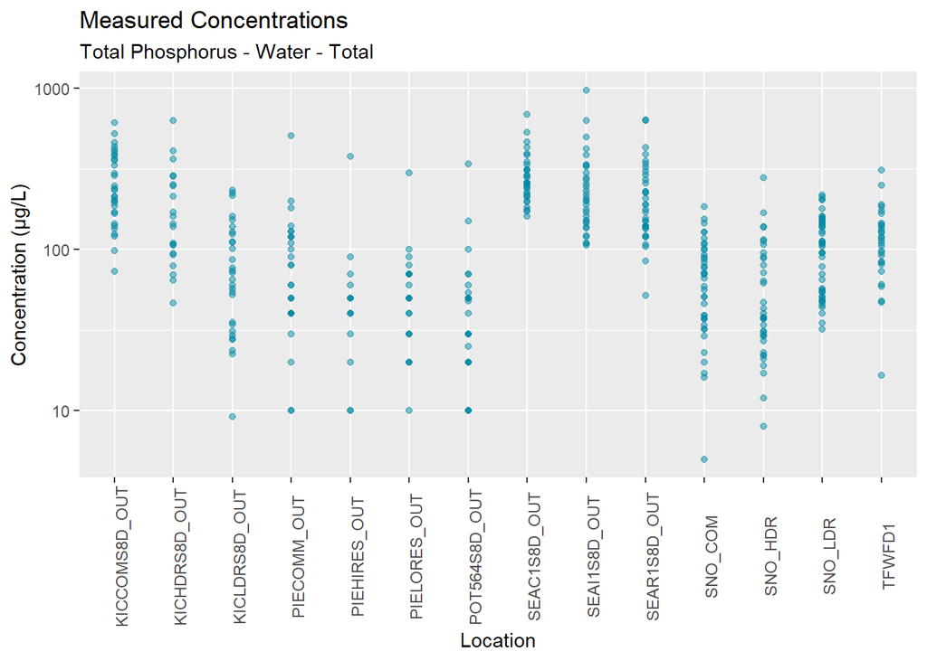

```
##
##
## Table: Variance inflation factors Total Phosphorus - Water - Total
##
##                      vif
## -----------------  -----
## nighttime_lights    4.43
## impervious          4.23
## rev_logTraffic      1.92
## logPopulation       1.87
## LU_ratio            1.30
## Linear mixed model fit by REML ['lmerMod']
## Formula: concentration ~ rev_logTraffic + (1 | Location)
##    Data: df.coc
##
## REML criterion at convergence: 5114
##
## Scaled residuals:
##    Min     1Q Median     3Q    Max
## -1.913 -0.530 -0.212  0.286  7.281
##
## Random effects:
##  Groups   Name        Variance Std.Dev.
##  Location (Intercept) 3158     56.2
##  Residual             9811     99.0
## Number of obs: 424, groups:  Location, 14
##
## Fixed effects:
##                Estimate Std. Error t value
## (Intercept)       478.1       82.9    5.77
## rev_logTraffic    214.0       51.6    4.15
##
## Correlation of Fixed Effects:
##             (Intr)
## rev_lgTrffc 0.982
```

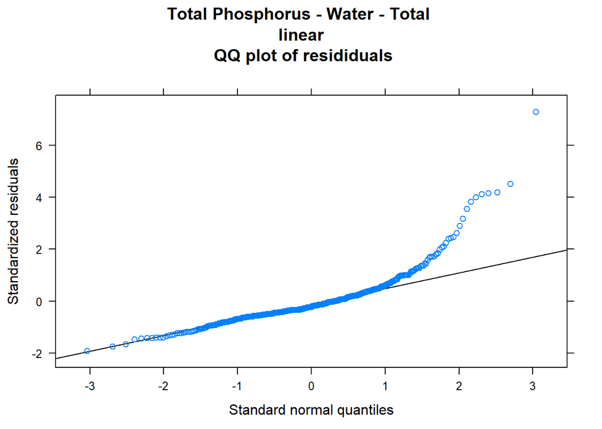

```
## Linear mixed model fit by REML ['lmerMod']
## Formula: log(concentration) ~ rev_logTraffic + (1 | Location)
##    Data: df.coc
##
## REML criterion at convergence: 902
##
## Scaled residuals:
##    Min     1Q Median     3Q    Max
## -3.614 -0.661  0.002  0.682  3.335
##
## Random effects:
##  Groups   Name        Variance Std.Dev.
##  Location (Intercept) 0.221    0.47
##  Residual             0.449    0.67
## Number of obs: 424, groups:  Location, 14
##
## Fixed effects:
##                Estimate Std. Error t value
## (Intercept)       7.207      0.682   10.57
## rev_logTraffic    1.694      0.424    3.99
##
## Correlation of Fixed Effects:
##             (Intr)
## rev_lgTrffc 0.982
```

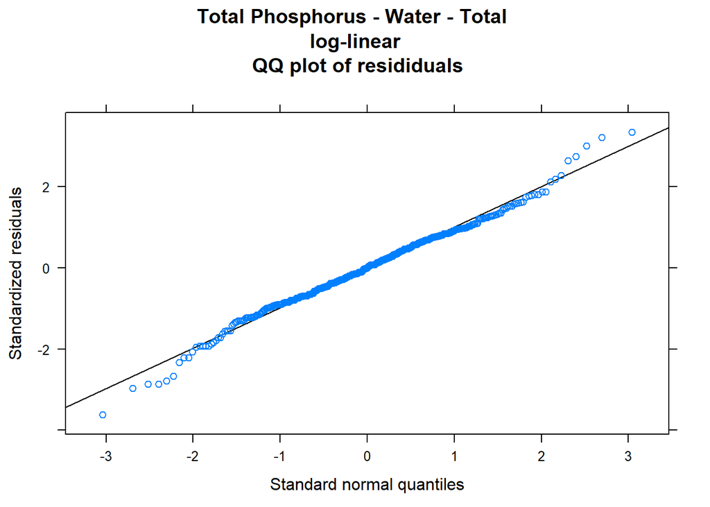

Total Phosphorus - Water - Total

|  | linear |  |  | log-linear |  |  | linear seasonal |  |  | log-linear seasonal |  |  |
| --- | --- | --- | --- | --- | --- | --- | --- | --- | --- | --- | --- | --- |
| Predictors | Estimates | CI | p | Estimates | CI | p | Estimates | CI | p | Estimates | CI | p |
| (Intercept) | 478.14 | 315.58 – 640.69 | **<0.001** | 7.21 | 5.87 – 8.54 | **<0.001** | 468.29 | 302.21 – 634.37 | **<0.001** | 7.08 | 5.74 – 8.42 | **<0.001** |
| rev_logTraffic | 214.01 | 112.86 – 315.16 | **<0.001** | 1.69 | 0.86 – 2.53 | **<0.001** | 214.28 | 111.18 – 317.38 | **<0.001** | 1.68 | 0.85 – 2.51 | **<0.001** |
| season [2] |  |  |  |  |  |  | -12.04 | -38.11 – 14.02 | 0.365 | -0.11 | -0.28 – 0.07 | 0.225 |
| season [3] |  |  |  |  |  |  | 95.37 | 64.16 – 126.59 | **<0.001** | 0.77 | 0.56 – 0.98 | **<0.001** |
| season [4] |  |  |  |  |  |  | 8.70 | -13.09 – 30.49 | 0.434 | 0.15 | 0.00 – 0.29 | **0.048** |
| Random Effects |  |  |  |  |  |  |  |  |  |  |  |  |
| σ<sup>2</sup> | 9810.78 |  |  | 0.45 |  |  | 8919.81 |  |  | 0.39 |  |  |
| τ<sub>00</sub> | 3158.19 <sub>Location</sub> |  |  | 0.22 <sub>Location</sub> |  |  | 3317.80 <sub>Location</sub> |  |  | 0.22 <sub>Location</sub> |  |  |
| ICC | 0.24 |  |  | 0.33 |  |  | 0.27 |  |  | 0.36 |  |  |
| N | 14 <sub>Location</sub> |  |  | 14 <sub>Location</sub> |  |  | 14 <sub>Location</sub> |  |  | 14 <sub>Location</sub> |  |  |
| Observations | 424 |  |  | 424 |  |  | 424 |  |  | 424 |  |  |
| Marginal R<sup>2</sup> / Conditional R<sup>2</sup> | 0.251 / 0.434 |  |  | 0.289 / 0.524 |  |  | 0.298 / 0.488 |  |  | 0.349 / 0.586 |  |  |
| AIC | 5122.122 |  |  | 909.735 |  |  | 5065.815 |  |  | 863.509 |  |  |

```r
show_results(5)
```

## Total Suspended Solids

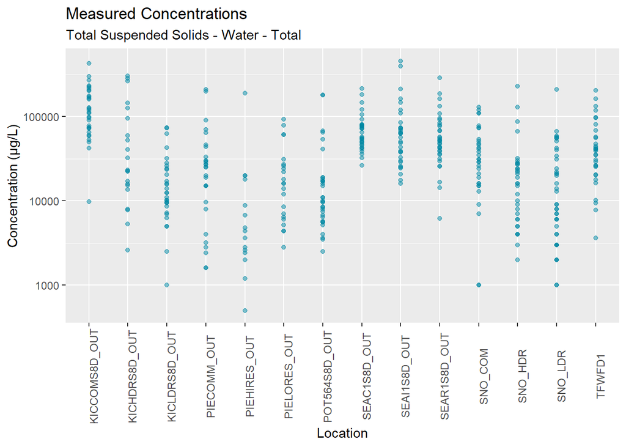

```
##
##
## Table: Variance inflation factors Total Suspended Solids - Water - Total
##
##                      vif
## -----------------  -----
## nighttime_lights    4.45
## impervious          4.23
## rev_logTraffic      1.93
## logPopulation       1.89
## LU_ratio            1.30
## Linear mixed model fit by REML ['lmerMod']
## Formula: concentration ~ rev_logTraffic + (1 | Location)
##    Data: df.coc
##
## REML criterion at convergence: 10252
##
## Scaled residuals:
##    Min     1Q Median     3Q    Max
## -2.073 -0.444 -0.265  0.046  6.520
##
## Random effects:
##  Groups   Name        Variance Std.Dev.
##  Location (Intercept) 6.83e+08 26128
##  Residual             3.26e+09 57092
## Number of obs: 415, groups:  Location, 14
##
## Fixed effects:
##                Estimate Std. Error t value
## (Intercept)      152053      39520    3.85
## rev_logTraffic    63942      24614    2.60
##
## Correlation of Fixed Effects:
##             (Intr)
## rev_lgTrffc 0.982
```

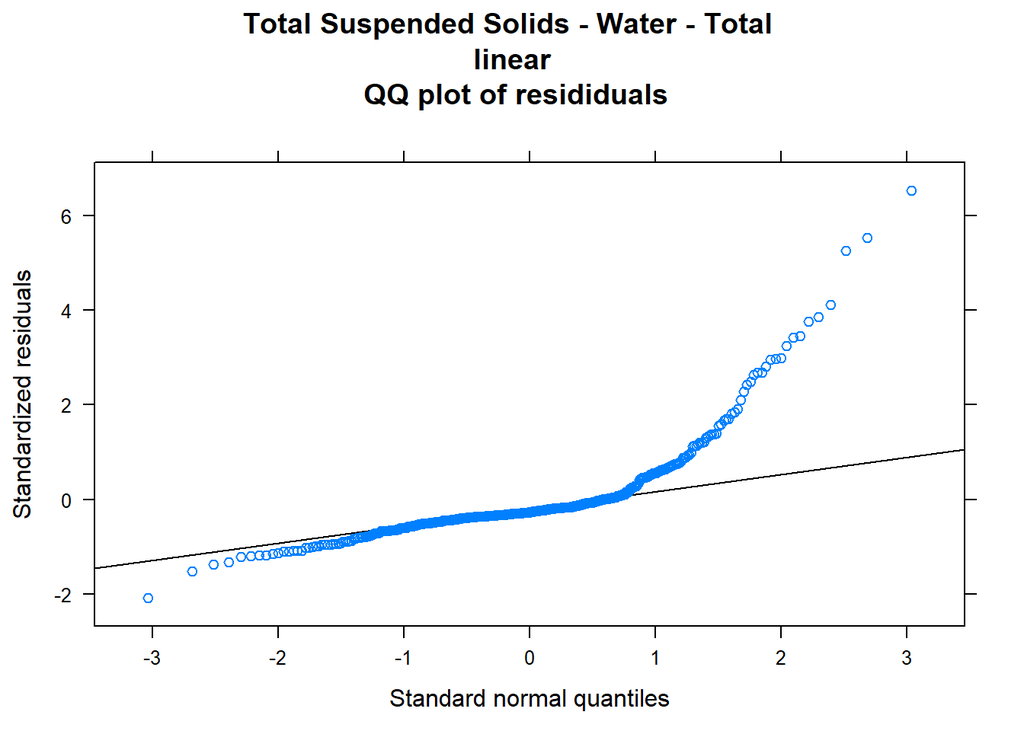

```
## Linear mixed model fit by REML ['lmerMod']
## Formula: log(concentration) ~ rev_logTraffic + (1 | Location)
##    Data: df.coc
##
## REML criterion at convergence: 1233
##
## Scaled residuals:
##    Min     1Q Median     3Q    Max
## -3.152 -0.587  0.013  0.557  3.272
##
## Random effects:
##  Groups   Name        Variance Std.Dev.
##  Location (Intercept) 0.28     0.53
##  Residual             1.06     1.03
## Number of obs: 415, groups:  Location, 14
##
## Fixed effects:
##                Estimate Std. Error t value
## (Intercept)      13.198      0.790   16.72
## rev_logTraffic    1.946      0.492    3.96
##
## Correlation of Fixed Effects:
##             (Intr)
## rev_lgTrffc 0.982
```

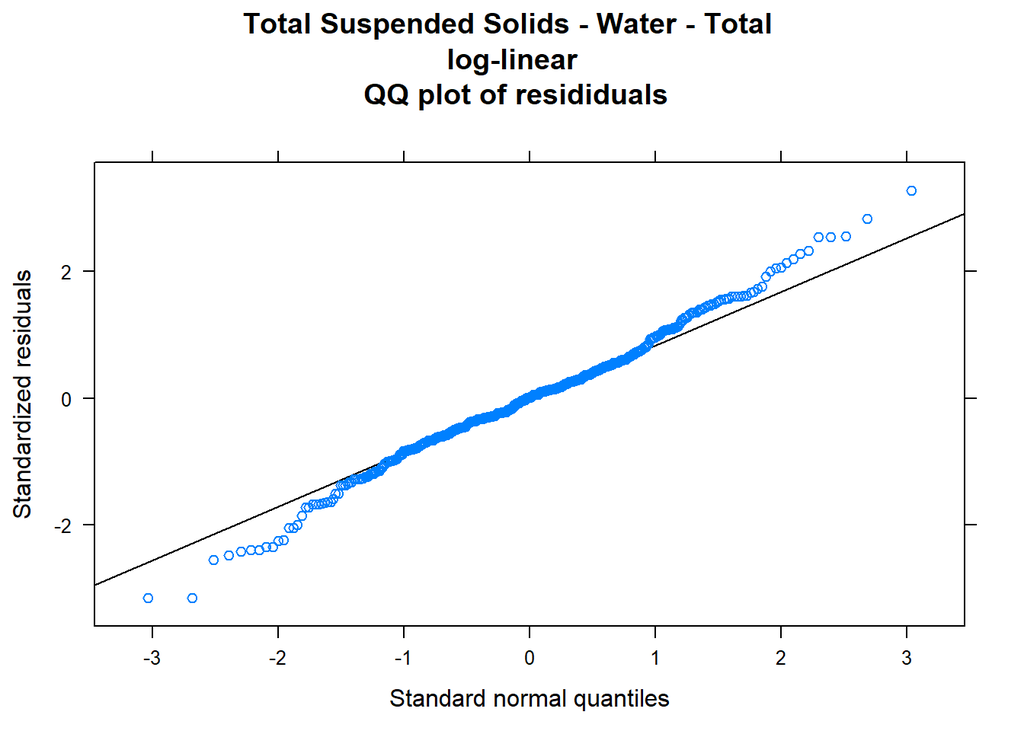

Total Suspended Solids - Water - Total

|  | linear |  |  | log-linear |  |  | linear seasonal |  |  | log-linear seasonal |  |  |
| --- | --- | --- | --- | --- | --- | --- | --- | --- | --- | --- | --- | --- |
| Predictors | Estimates | CI | p | Estimates | CI | p | Estimates | CI | p | Estimates | CI | p |
| (Intercept) | 152052.47 | 74594.11 – 229510.83 | **<0.001** | 13.20 | 11.65 – 14.75 | **<0.001** | 152052.47 | 74594.11 – 229510.83 | **<0.001** | 13.20 | 11.65 – 14.75 | **<0.001** |
| rev_logTraffic | 63941.48 | 15699.51 – 112183.45 | **0.009** | 1.95 | 0.98 – 2.91 | **<0.001** | 63941.48 | 15699.51 – 112183.45 | **0.009** | 1.95 | 0.98 – 2.91 | **<0.001** |
| Random Effects |  |  |  |  |  |  |  |  |  |  |  |  |
| σ<sup>2</sup> | 3259447964.46 |  |  | 1.06 |  |  | 3259447964.46 |  |  | 1.06 |  |  |
| τ<sub>00</sub> | 682696191.57 <sub>Location</sub> |  |  | 0.28 <sub>Location</sub> |  |  | 682696191.57 <sub>Location</sub> |  |  | 0.28 <sub>Location</sub> |  |  |
| ICC | 0.17 |  |  | 0.21 |  |  | 0.17 |  |  | 0.21 |  |  |
| N | 14 <sub>Location</sub> |  |  | 14 <sub>Location</sub> |  |  | 14 <sub>Location</sub> |  |  | 14 <sub>Location</sub> |  |  |
| Observations | 415 |  |  | 415 |  |  | 415 |  |  | 415 |  |  |
| Marginal R<sup>2</sup> / Conditional R<sup>2</sup> | 0.090 / 0.248 |  |  | 0.213 / 0.377 |  |  | 0.090 / 0.248 |  |  | 0.213 / 0.377 |  |  |
| AIC | 10259.857 |  |  | 1240.983 |  |  | 10259.857 |  |  | 1240.983 |  |  |

```r
show_results(6)
```

## Total Phthalate

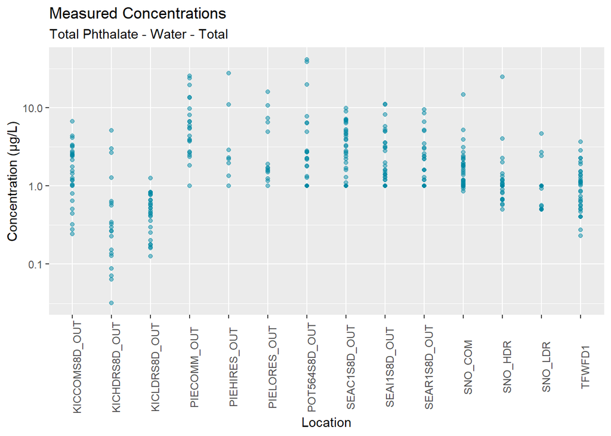

```
##
##
## Table: Variance inflation factors Total Phthalate - Water - Total
##
##                      vif
## -----------------  -----
## nighttime_lights    4.47
## impervious          4.23
## rev_logTraffic      1.91
## logPopulation       1.88
## LU_ratio            1.30
## Linear mixed model fit by REML ['lmerMod']
## Formula: concentration ~ (1 | Location)
##    Data: df.coc
##
## REML criterion at convergence: 2343
##
## Scaled residuals:
##    Min     1Q Median     3Q    Max
## -1.512 -0.337 -0.160  0.005  9.109
##
## Random effects:
##  Groups   Name        Variance Std.Dev.
##  Location (Intercept)  3.88    1.97
##  Residual             16.20    4.02
## Number of obs: 412, groups:  Location, 14
##
## Fixed effects:
##             Estimate Std. Error t value
## (Intercept)    2.896      0.568    5.09
```

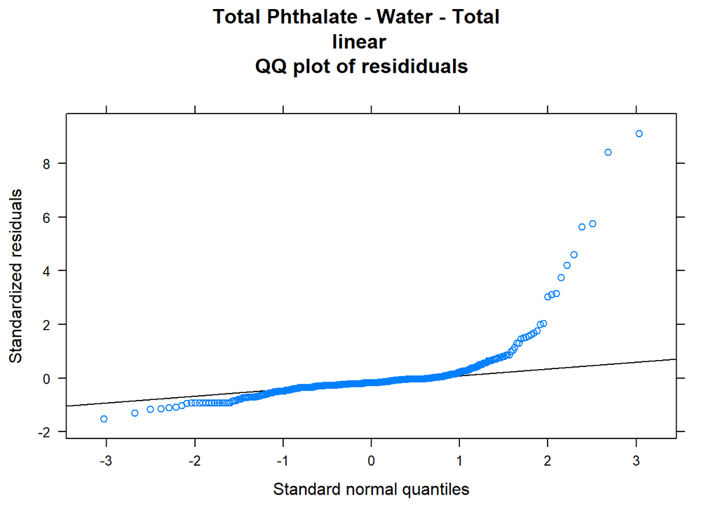

```
## Linear mixed model fit by REML ['lmerMod']
## Formula: log(concentration) ~ (1 | Location)
##    Data: df.coc
##
## REML criterion at convergence: 1008
##
## Scaled residuals:
##    Min     1Q Median     3Q    Max
## -3.095 -0.717 -0.114  0.485  4.008
##
## Random effects:
##  Groups   Name        Variance Std.Dev.
##  Location (Intercept) 0.580    0.762
##  Residual             0.604    0.777
## Number of obs: 412, groups:  Location, 14
##
## Fixed effects:
##             Estimate Std. Error t value
## (Intercept)    0.418      0.208    2.01
```

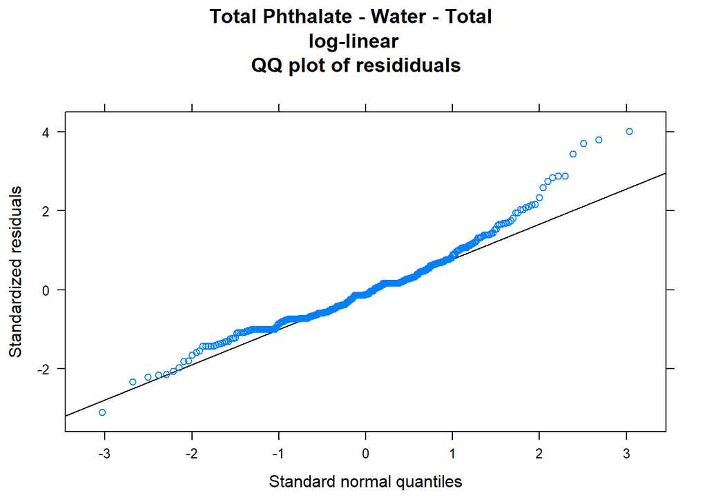

Total Phthalate - Water - Total

|  | linear |  |  | log-linear |  |  | linear seasonal |  |  | log-linear seasonal |  |  |
| --- | --- | --- | --- | --- | --- | --- | --- | --- | --- | --- | --- | --- |
| Predictors | Estimates | CI | p | Estimates | CI | p | Estimates | CI | p | Estimates | CI | p |
| (Intercept) | 2.90 | 1.78 – 4.01 | **<0.001** | 0.42 | 0.01 – 0.83 | **0.044** | 2.90 | 1.78 – 4.01 | **<0.001** | 0.42 | 0.01 – 0.83 | **0.044** |
| Random Effects |  |  |  |  |  |  |  |  |  |  |  |  |
| σ<sup>2</sup> | 16.20 |  |  | 0.60 |  |  | 16.20 |  |  | 0.60 |  |  |
| τ<sub>00</sub> | 3.88 <sub>Location</sub> |  |  | 0.58 <sub>Location</sub> |  |  | 3.88 <sub>Location</sub> |  |  | 0.58 <sub>Location</sub> |  |  |
| ICC | 0.19 |  |  | 0.49 |  |  | 0.19 |  |  | 0.49 |  |  |
| N | 14 <sub>Location</sub> |  |  | 14 <sub>Location</sub> |  |  | 14 <sub>Location</sub> |  |  | 14 <sub>Location</sub> |  |  |
| Observations | 412 |  |  | 412 |  |  | 412 |  |  | 412 |  |  |
| Marginal R<sup>2</sup> / Conditional R<sup>2</sup> | 0.000 / 0.193 |  |  | 0.000 / 0.490 |  |  | 0.000 / 0.193 |  |  | 0.000 / 0.490 |  |  |
| AIC | 2349.218 |  |  | 1013.961 |  |  | 2349.218 |  |  | 1013.961 |  |  |

```r
show_results(7)
```

## Total PAH

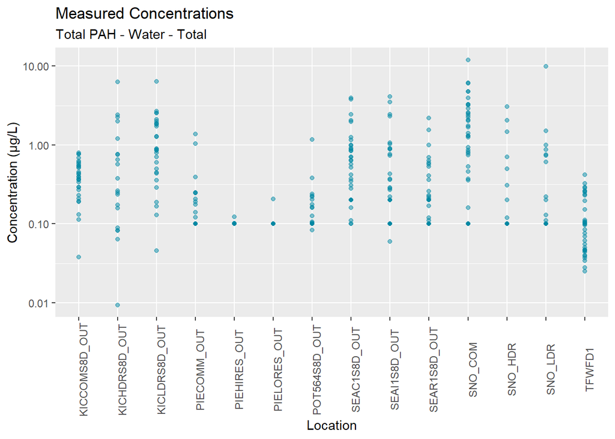

```
##
##
## Table: Variance inflation factors Total PAH - Water - Total
##
##                      vif
## -----------------  -----
## nighttime_lights    4.48
## impervious          4.23
## rev_logTraffic      1.91
## logPopulation       1.88
## LU_ratio            1.29
## Linear mixed model fit by REML ['lmerMod']
## Formula: concentration ~ (1 | Location)
##    Data: df.coc
##
## REML criterion at convergence: 1267
##
## Scaled residuals:
##    Min     1Q Median     3Q    Max
## -1.648 -0.311 -0.159  0.016  9.223
##
## Random effects:
##  Groups   Name        Variance Std.Dev.
##  Location (Intercept) 0.271    0.521
##  Residual             1.182    1.087
## Number of obs: 412, groups:  Location, 14
##
## Fixed effects:
##             Estimate Std. Error t value
## (Intercept)    0.592      0.151    3.93
```

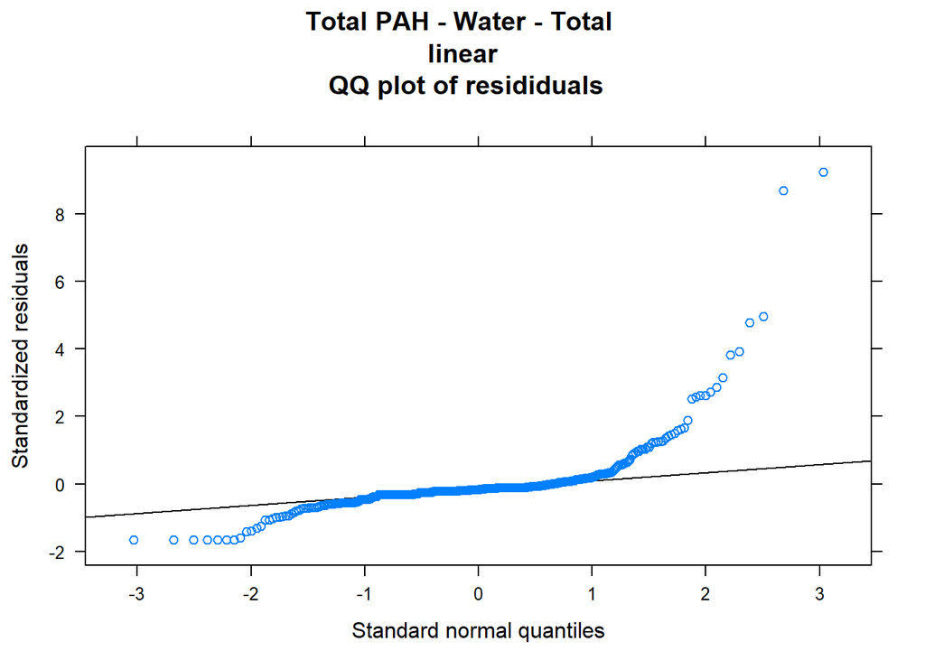

```
## Linear mixed model fit by REML ['lmerMod']
## Formula: log(concentration) ~ LU_ratio + (1 | Location)
##    Data: df.coc
##
## REML criterion at convergence: 1191
##
## Scaled residuals:
##    Min     1Q Median     3Q    Max
## -3.710 -0.453 -0.186  0.551  4.235
##
## Random effects:
##  Groups   Name        Variance Std.Dev.
##  Location (Intercept) 0.414    0.644
##  Residual             0.960    0.980
## Number of obs: 412, groups:  Location, 14
##
## Fixed effects:
##             Estimate Std. Error t value
## (Intercept)  -1.4436     0.1804   -8.00
## LU_ratio     -0.1607     0.0696   -2.31
##
## Correlation of Fixed Effects:
##          (Intr)
## LU_ratio 0.072
```

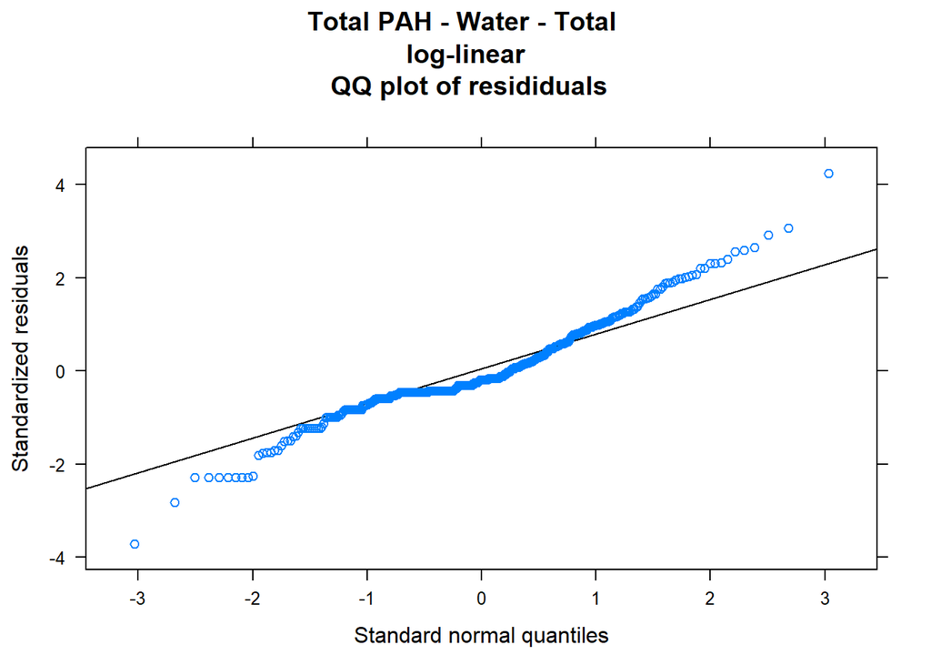

Total PAH - Water - Total

|  | linear |  |  | log-linear |  |  | linear seasonal |  |  | log-linear seasonal |  |  |
| --- | --- | --- | --- | --- | --- | --- | --- | --- | --- | --- | --- | --- |
| Predictors | Estimates | CI | p | Estimates | CI | p | Estimates | CI | p | Estimates | CI | p |
| (Intercept) | 0.59 | 0.30 – 0.89 | **<0.001** | -1.44 | -1.80 – -1.09 | **<0.001** | 0.59 | 0.30 – 0.89 | **<0.001** | -1.36 | -1.73 – -0.99 | **<0.001** |
| LU_ratio |  |  |  | -0.16 | -0.30 – -0.02 | **0.021** |  |  |  | -0.16 | -0.29 – -0.02 | **0.022** |
| season [2] |  |  |  |  |  |  |  |  |  | -0.32 | -0.59 – -0.04 | **0.025** |
| season [3] |  |  |  |  |  |  |  |  |  | -0.31 | -0.63 – 0.02 | 0.066 |
| season [4] |  |  |  |  |  |  |  |  |  | 0.04 | -0.19 – 0.26 | 0.757 |
| Random Effects |  |  |  |  |  |  |  |  |  |  |  |  |
| σ<sup>2</sup> | 1.18 |  |  | 0.96 |  |  | 1.18 |  |  | 0.95 |  |  |
| τ<sub>00</sub> | 0.27 <sub>Location</sub> |  |  | 0.41 <sub>Location</sub> |  |  | 0.27 <sub>Location</sub> |  |  | 0.40 <sub>Location</sub> |  |  |
| ICC | 0.19 |  |  | 0.30 |  |  | 0.19 |  |  | 0.30 |  |  |
| N | 14 <sub>Location</sub> |  |  | 14 <sub>Location</sub> |  |  | 14 <sub>Location</sub> |  |  | 14 <sub>Location</sub> |  |  |
| Observations | 412 |  |  | 412 |  |  | 412 |  |  | 412 |  |  |
| Marginal R<sup>2</sup> / Conditional R<sup>2</sup> | 0.000 / 0.187 |  |  | 0.122 / 0.387 |  |  | 0.000 / 0.187 |  |  | 0.136 / 0.392 |  |  |
| AIC | 1273.036 |  |  | 1199.303 |  |  | 1273.036 |  |  | 1202.326 |  |  |

```r
show_results(8)
```

## CPAH

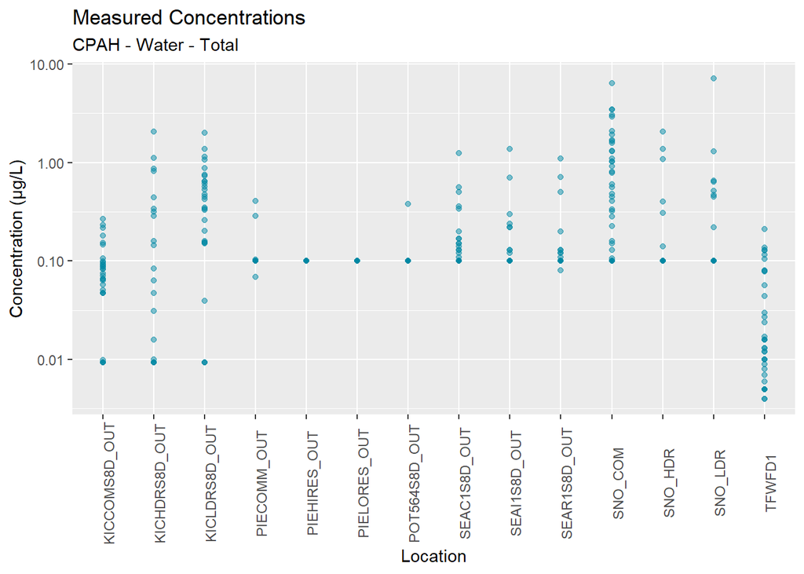

```
##
##
## Table: Variance inflation factors CPAH - Water - Total
##
##                      vif
## -----------------  -----
## nighttime_lights    4.52
## impervious          4.24
## rev_logTraffic      1.89
## logPopulation       1.88
## LU_ratio            1.29
## Linear mixed model fit by REML ['lmerMod']
## Formula: concentration ~ logPopulation + rev_logTraffic + (1 | Location)
##    Data: df.coc
##
## REML criterion at convergence: 755
##
## Scaled residuals:
##    Min     1Q Median     3Q    Max
## -1.510 -0.244 -0.125  0.050 11.592
##
## Random effects:
##  Groups   Name        Variance Std.Dev.
##  Location (Intercept) 0.0289   0.170
##  Residual             0.3455   0.588
## Number of obs: 412, groups:  Location, 14
##
## Fixed effects:
##                Estimate Std. Error t value
## (Intercept)     -0.6946     0.3332   -2.08
## logPopulation    0.1494     0.0472    3.16
## rev_logTraffic  -0.6404     0.2147   -2.98
##
## Correlation of Fixed Effects:
##             (Intr) lgPplt
## logPopulatn -0.521
## rev_lgTrffc  0.986 -0.555
```

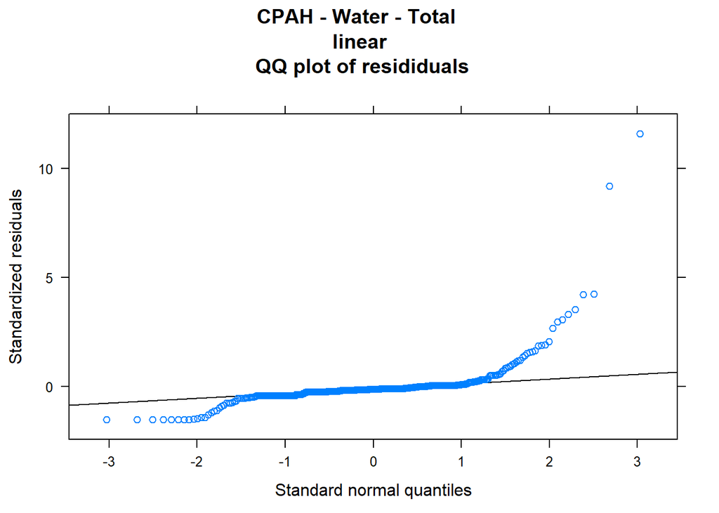

```
## Linear mixed model fit by REML ['lmerMod']
## Formula: log(concentration) ~ LU_ratio + (1 | Location)
##    Data: df.coc
##
## REML criterion at convergence: 1157
##
## Scaled residuals:
##    Min     1Q Median     3Q    Max
## -3.483 -0.355 -0.159  0.273  4.166
##
## Random effects:
##  Groups   Name        Variance Std.Dev.
##  Location (Intercept) 0.266    0.516
##  Residual             0.892    0.944
## Number of obs: 412, groups:  Location, 14
##
## Fixed effects:
##             Estimate Std. Error t value
## (Intercept)  -2.1727     0.1471  -14.77
## LU_ratio     -0.1884     0.0566   -3.33
##
## Correlation of Fixed Effects:
##          (Intr)
## LU_ratio 0.073
```

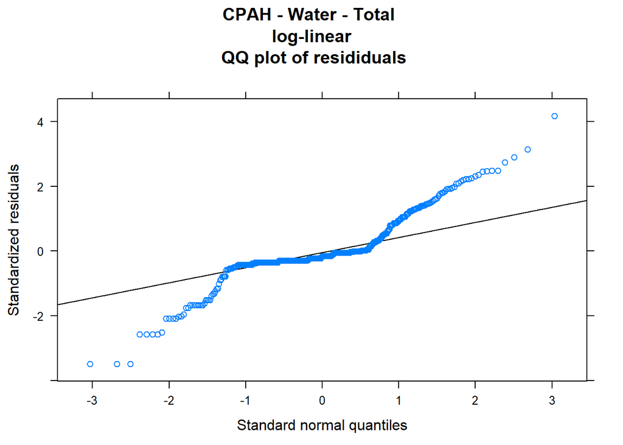

CPAH - Water - Total

|  | linear |  |  | log-linear |  |  | linear seasonal |  |  | log-linear seasonal |  |  |
| --- | --- | --- | --- | --- | --- | --- | --- | --- | --- | --- | --- | --- |
| Predictors | Estimates | CI | p | Estimates | CI | p | Estimates | CI | p | Estimates | CI | p |
| (Intercept) | -0.69 | -1.35 – -0.04 | **0.037** | -2.17 | -2.46 – -1.88 | **<0.001** | -0.69 | -1.35 – -0.04 | **0.037** | -2.17 | -2.46 – -1.88 | **<0.001** |
| logPopulation | 0.15 | 0.06 – 0.24 | **0.002** |  |  |  | 0.15 | 0.06 – 0.24 | **0.002** |  |  |  |
| rev_logTraffic | -0.64 | -1.06 – -0.22 | **0.003** |  |  |  | -0.64 | -1.06 – -0.22 | **0.003** |  |  |  |
| LU_ratio |  |  |  | -0.19 | -0.30 – -0.08 | **0.001** |  |  |  | -0.19 | -0.30 – -0.08 | **0.001** |
| Random Effects |  |  |  |  |  |  |  |  |  |  |  |  |
| σ<sup>2</sup> | 0.35 |  |  | 0.89 |  |  | 0.35 |  |  | 0.89 |  |  |
| τ<sub>00</sub> | 0.03 <sub>Location</sub> |  |  | 0.27 <sub>Location</sub> |  |  | 0.03 <sub>Location</sub> |  |  | 0.27 <sub>Location</sub> |  |  |
| ICC | 0.08 |  |  | 0.23 |  |  | 0.08 |  |  | 0.23 |  |  |
| N | 14 <sub>Location</sub> |  |  | 14 <sub>Location</sub> |  |  | 14 <sub>Location</sub> |  |  | 14 <sub>Location</sub> |  |  |
| Observations | 412 |  |  | 412 |  |  | 412 |  |  | 412 |  |  |
| Marginal R<sup>2</sup> / Conditional R<sup>2</sup> | 0.096 / 0.166 |  |  | 0.185 / 0.372 |  |  | 0.096 / 0.166 |  |  | 0.185 / 0.372 |  |  |
| AIC | 765.133 |  |  | 1165.104 |  |  | 765.133 |  |  | 1165.104 |  |  |

```r
show_results(9)
```

##HPAH

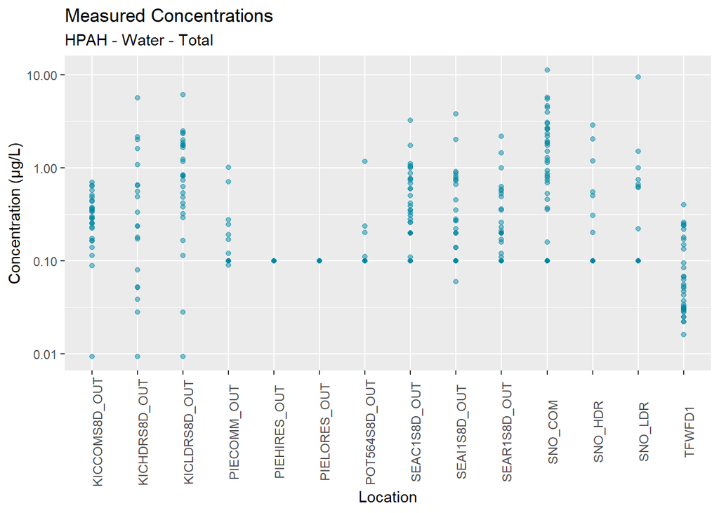

```
##
##
## Table: Variance inflation factors HPAH - Water - Total
##
##                      vif
## -----------------  -----
## nighttime_lights    4.48
## impervious          4.23
## rev_logTraffic      1.91
## logPopulation       1.88
## LU_ratio            1.29
## Linear mixed model fit by REML ['lmerMod']
## Formula: concentration ~ (1 | Location)
##    Data: df.coc
##
## REML criterion at convergence: 1194
##
## Scaled residuals:
##    Min     1Q Median     3Q    Max
## -1.673 -0.316 -0.142  0.001  9.555
##
## Random effects:
##  Groups   Name        Variance Std.Dev.
##  Location (Intercept) 0.234    0.484
##  Residual             0.990    0.995
## Number of obs: 412, groups:  Location, 14
##
## Fixed effects:
##             Estimate Std. Error t value
## (Intercept)    0.509      0.140    3.65
```

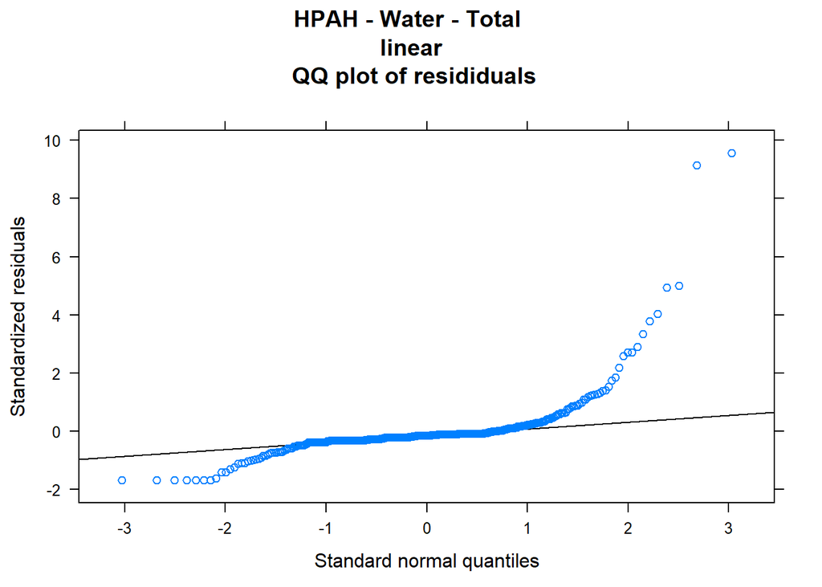

```
## Linear mixed model fit by REML ['lmerMod']
## Formula: log(concentration) ~ LU_ratio + (1 | Location)
##    Data: df.coc
##
## REML criterion at convergence: 1199
##
## Scaled residuals:
##    Min     1Q Median     3Q    Max
## -4.192 -0.410 -0.167  0.539  4.187
##
## Random effects:
##  Groups   Name        Variance Std.Dev.
##  Location (Intercept) 0.361    0.601
##  Residual             0.982    0.991
## Number of obs: 412, groups:  Location, 14
##
## Fixed effects:
##             Estimate Std. Error t value
## (Intercept)  -1.6083     0.1697   -9.48
## LU_ratio     -0.1736     0.0653   -2.66
##
## Correlation of Fixed Effects:
##          (Intr)
## LU_ratio 0.072
```

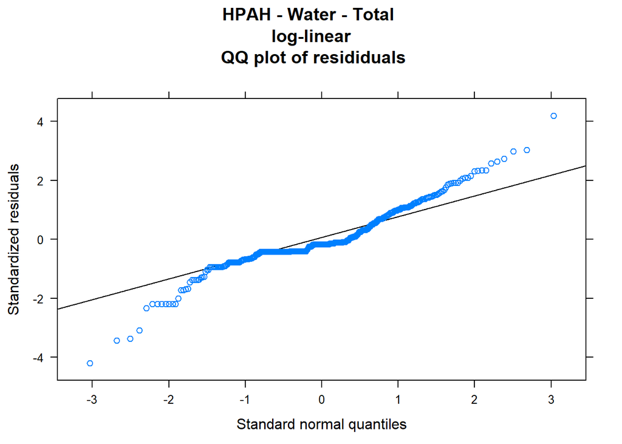

HPAH - Water - Total

|  | linear |  |  | log-linear |  |  | linear seasonal |  |  | log-linear seasonal |  |  |
| --- | --- | --- | --- | --- | --- | --- | --- | --- | --- | --- | --- | --- |
| Predictors | Estimates | CI | p | Estimates | CI | p | Estimates | CI | p | Estimates | CI | p |
| (Intercept) | 0.51 | 0.24 – 0.78 | **<0.001** | -1.61 | -1.94 – -1.28 | **<0.001** | 0.51 | 0.24 – 0.78 | **<0.001** | -1.61 | -1.94 – -1.28 | **<0.001** |
| LU_ratio |  |  |  | -0.17 | -0.30 – -0.05 | **0.008** |  |  |  | -0.17 | -0.30 – -0.05 | **0.008** |
| Random Effects |  |  |  |  |  |  |  |  |  |  |  |  |
| σ<sup>2</sup> | 0.99 |  |  | 0.98 |  |  | 0.99 |  |  | 0.98 |  |  |
| τ<sub>00</sub> | 0.23 <sub>Location</sub> |  |  | 0.36 <sub>Location</sub> |  |  | 0.23 <sub>Location</sub> |  |  | 0.36 <sub>Location</sub> |  |  |
| ICC | 0.19 |  |  | 0.27 |  |  | 0.19 |  |  | 0.27 |  |  |
| N | 14 <sub>Location</sub> |  |  | 14 <sub>Location</sub> |  |  | 14 <sub>Location</sub> |  |  | 14 <sub>Location</sub> |  |  |
| Observations | 412 |  |  | 412 |  |  | 412 |  |  | 412 |  |  |
| Marginal R<sup>2</sup> / Conditional R<sup>2</sup> | 0.000 / 0.191 |  |  | 0.143 / 0.373 |  |  | 0.000 / 0.191 |  |  | 0.143 / 0.373 |  |  |
| AIC | 1200.321 |  |  | 1206.656 |  |  | 1200.321 |  |  | 1206.656 |  |  |

```r
show_results(10)
```